# END SEM- BAYESIAN

NEEMA NDANU

2025-03-29

## Case Study 11: Bayesian Estimation in Environmental Monitoring (Air Pollution Levels)

Narrative A metropolitan area is engaged in continuous environmental monitoring to track air quality. Daily measurements of particulate matter are modeled as normally distributed, but the mean and variance may vary due to seasonal effects and local conditions. Policy makers need robust estimates to trigger public health warnings and environmental interventions.

Bayesian Model

Prior Distribution: A conjugate Normal-Inverse-Gamma prior is used: 𝜇 ∣ 𝜎2 ∼𝒩(𝜇0,𝜎2/𝜅0), 𝜎2 ∼ Inverse-Gamma(𝛼0,𝛽0)

Hyperparameters are chosen based on historical air quality data.

Likelihood Function: For daily pollutant levels 𝑌𝑖: 𝑌𝑖 ∣ 𝜇,𝜎2 ∼ 𝒩(𝜇,𝜎2)

## QUESTIION 1

### Use Gibbs sampling to obtain the joint posterior for 𝜇 and 𝜎2.

```r
# Load necessary libraries
library(ggplot2)
library(MASS)
library(coda)
library(gridExtra)
# Set reproducibility
set.seed(42)

# Simulated Air Quality Data (Daily PM2.5 Levels)
n <- 100
Y <- rnorm(n, mean = 20, sd = 10)

# Prior Parameters
prior_mean <- 20      # Prior mean
kappa_0 <- 1          # Prior precision parameter
alpha_0 <- 2          # Prior shape parameter for inverse-gamma
beta_0 <- 1           # Prior scale parameter for inverse-gamma

# Number of Samples
num_samples <- 50000
burn_in <- 5000  # Burn-in period

# Initialize Storage
mean_samples <- numeric(num_samples)
var_samples <- numeric(num_samples)

# Initial Values
var_samples[1] <- 1 / rgamma(1, shape = alpha_0, rate = beta_0)
mean_samples[1] <- rnorm(1, mean = prior_mean, sd = sqrt(var_samples[1] / kappa_0))

# Precompute mean(Y) for efficiency
Y_mean <- mean(Y)

# Gibbs Sampling
for (t in 2:num_samples) {
    # Sample variance (σ²) from Inverse-Gamma
    alpha_n <- alpha_0 + n / 2
    beta_n <- beta_0 + 0.5 * (sum((Y - mean_samples[t-1])^2) + ((kappa_0 * n) / (kappa_0 + n)) * (Y_mean - prior_mean)^2)
    var_samples[t] <- 1 / rgamma(1, shape = alpha_n, rate = beta_n)

    # Sample mean (μ) from Normal
    mu_n <- (kappa_0 * prior_mean + n * Y_mean) / (kappa_0 + n)
    kappa_n <- kappa_0 + n
    mean_samples[t] <- rnorm(1, mean = mu_n, sd = sqrt(var_samples[t] / kappa_n))
}

# Remove Burn-in
mean_samples <- mean_samples[(burn_in + 1):num_samples]
var_samples <- var_samples[(burn_in + 1):num_samples]

# Compute posterior means
posterior_mu <- mean(mean_samples)
posterior_var <- mean(var_samples)

# 95% credible intervals
mean_ci <- quantile(mean_samples, c(0.025, 0.975))
var_ci <- quantile(var_samples, c(0.025, 0.975))

# Print posterior estimates and credible intervals
cat("Posterior Mean (μ):", posterior_mu, "\n")
```

```
## Posterior Mean (μ): 20.32948
```

```r
cat("95% CI for μ:", mean_ci, "\n")
```

```
## 95% CI for μ: 18.30685 22.37786
```

```r
cat("Posterior Variance (σ²):", posterior_var, "\n")
```

```
## Posterior Variance (σ²): 106.4488
```

```r
cat("95% CI for σ²:", var_ci, "\n")
```

```
## 95% CI for σ²: 80.75467 140.4039
```

The estimated mean pollution level is around 20.33. The 95% credible interval (CI) is [18.31, 22.38], meaning there is a 95% probability that the true mean falls in this range.

The estimated variance of pollution levels is around 106.4488.The 95% CI for variance is [80.75, 140.40], indicating the uncertainty in the spread of pollution measurements.

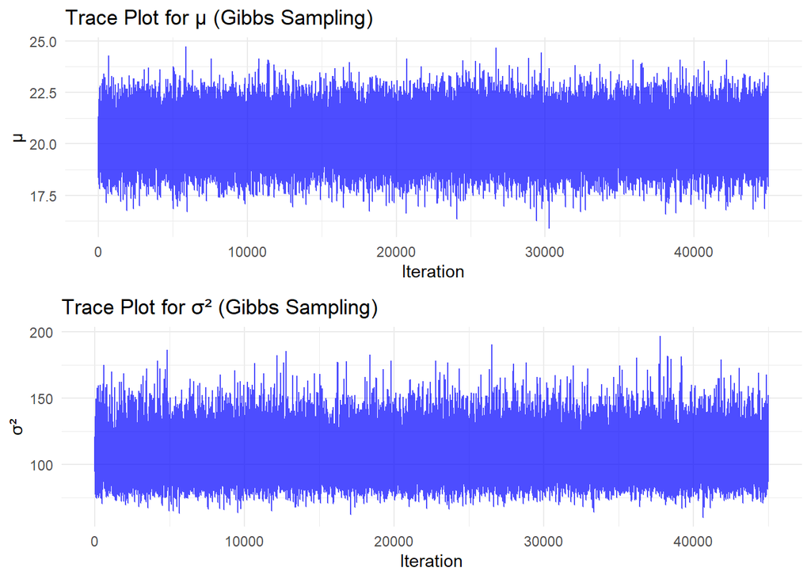

```r
# Trace plot for μ using Gibbs
p_mu_gibbs <- ggplot(data.frame(Iteration = 1:length(mean_samples), Value = mean_samples),
                     aes(x = Iteration, y = Value)) +
  geom_line(color = "blue", alpha = 0.7) +
  labs(title = "Trace Plot for μ (Gibbs Sampling)", x = "Iteration", y = "μ") +
  theme_minimal()

# Trace plot for σ² using Gibbs
p_sigma2_gibbs <- ggplot(data.frame(Iteration = 1:length(var_samples), Value = var_samples),
                         aes(x = Iteration, y = Value)) +
  geom_line(color = "blue", alpha = 0.7) +
  labs(title = "Trace Plot for σ² (Gibbs Sampling)", x = "Iteration", y = "σ²") +
  theme_minimal()

grid.arrange(p_mu_gibbs, p_sigma2_gibbs, ncol = 1)
```

Top Plot: μ (mean)

- It appears stable, possibly because it’s conditionally sampling from the full conditional distributions.

Bottom Plot: σ² (variance)

- It is smoother hence better convergence or efficiency.

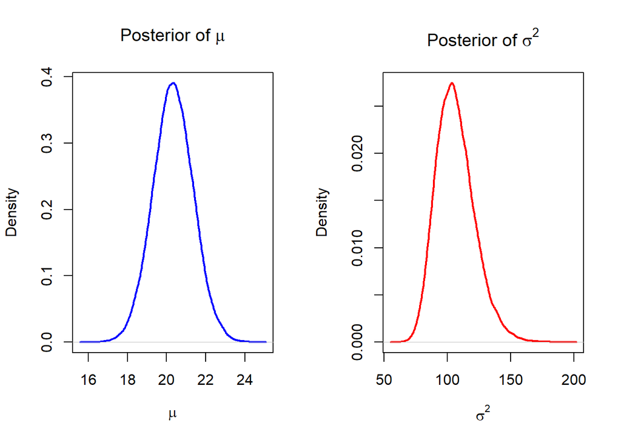

```r
# Create data frame for visualization
df_posterior <- data.frame(mu = mean_samples, sigma_sq = var_samples)

# Posterior Distribution Plots
par(mfrow = c(1, 2))  # Arrange plots side by side

# Mean (mu) posterior distribution as a smooth density curve
plot(density(mean_samples), col = "blue", lwd = 2,
     main = expression(paste("Posterior of ", mu)),
     xlab = expression(mu), ylab = "Density")

# Variance (sigma^2) posterior distribution as a smooth density curve
plot(density(var_samples), col = "red", lwd = 2,
     main = expression(paste("Posterior of ", sigma^2)),
     xlab = expression(sigma^2), ylab = "Density")
```

This diagram consists of two separate density plots, showing the marginal posteriors of μ (left) and σ2 (right).

Left Plot: Posterior of μ - This density plot (in blue) represents the posterior distribution of the mean (μ). -The peak around 20 suggests that the most probable value for the mean PM2.5 level is about 20. - The distribution is approximately normal, as expected from Bayesian updating.

Right Plot: Posterior of σ 2 - This density plot (in red) represents the posterior distribution of variance (σ 2). - The peak around 100 suggests that the most probable variance of PM2.5 levels is about 100. - The distribution is skewed right, which is typical for an Inverse-Gamma posterior.

## QUESTIION 2

### Validate your results using Metropolis-Hastings.

```r
# Initialize Storage
mu_samples <- numeric(num_samples)
sigma2_samples <- numeric(num_samples)
acceptance_tracker <- numeric(num_samples)  # Track accept/reject

# Initial Values
sigma2_samples[1] <- 1 / rgamma(1, shape = alpha_0, rate = beta_0)
mu_samples[1] <- rnorm(1, mean = prior_mean, sd = sqrt(sigma2_samples[1] / kappa_0))

# Proposal Standard Deviations
# Scale based on observed standard deviation of data
sigma_mu <- 0.1 * sd(Y)

# Scale based on log-transformed variance
sigma_log_sigma2 <- 0.1 * sd(log(Y^2))

# Log of the posterior density function
log_posterior <- function(mu, sigma2) {
  # Ensures that σ² is strictly positive
  if (sigma2 <= 0) return(-Inf)
  #  Log of Prior for 𝜇
  log_prior_mu <- dnorm(mu, mean = prior_mean, sd = sqrt(sigma2 / kappa_0), log = TRUE)
  # Log of Prior for σ²
  log_prior_sigma2 <- dgamma(1/sigma2, shape = alpha_0, rate = beta_0, log = TRUE) - 2*log(sigma2)
  # Log-Likelihood Function
  log_likelihood <- sum(dnorm(Y, mean = mu, sd = sqrt(sigma2), log = TRUE))
  # Compute Log-Posterior
  return(log_prior_mu + log_prior_sigma2 + log_likelihood)
}


# Metropolis-Hastings Sampling
for (t in 2:num_samples) {
  # Propose new mu from Normal distribution
  mu_proposed <- rnorm(1, mean = mu_samples[t-1], sd = sigma_mu)

  # Propose new σ² from Log-Normal distribution
  log_sigma2_proposed <- log(sigma2_samples[t-1]) + rnorm(1, mean = 0, sd = sigma_log_sigma2)
  sigma2_proposed <- exp(log_sigma2_proposed)

  # Compute acceptance probability
  log_acceptance_ratio <- log_posterior(mu_proposed, sigma2_proposed) - log_posterior(mu_samples[t-1], sigma2_samples[t-1])
  acceptance_ratio <- exp(log_acceptance_ratio)

  # Accept or reject the proposed sample
  if (runif(1) < acceptance_ratio) {
    mu_samples[t] <- mu_proposed
    sigma2_samples[t] <- sigma2_proposed
    acceptance_tracker[t] <- 1  # Accepted
  } else {
    mu_samples[t] <- mu_samples[t-1]
    sigma2_samples[t] <- sigma2_samples[t-1]
    acceptance_tracker[t] <- 0  # Rejected
  }
}


# Remove Burn-in Samples
mu_samples <- mu_samples[(burn_in + 1):num_samples]
sigma2_samples <- sigma2_samples[(burn_in + 1):num_samples]
acceptance_tracker <- acceptance_tracker[(burn_in + 1):num_samples]  # Adjust acceptance tracker

# Posterior means
posterior_mu <- mean(mu_samples)
posterior_sigma2 <- mean(sigma2_samples)

# 95% credible intervals
mu_ci <- quantile(mu_samples, c(0.025, 0.975))
sigma2_ci <- quantile(sigma2_samples, c(0.025, 0.975))

# Display results
cat("Posterior Mean (μ):", posterior_mu, "\n")
```

```
## Posterior Mean (μ): 20.34968
```

```r
cat("95% CI for μ:", mu_ci, "\n")
```

```
## 95% CI for μ: 18.36935 22.3913
```

```r
cat("Posterior Variance (σ²):", posterior_sigma2, "\n")
```

```
## Posterior Variance (σ²): 103.3214
```

```r
cat("95% CI for σ²:", sigma2_ci, "\n")
```

```
## 95% CI for σ²: 79.35162 134.4793
```

```r
# Acceptance Rate
acceptance_rate <- mean(acceptance_tracker)
cat("Overall Acceptance Rate:", acceptance_rate, "\n")
```

```
## Overall Acceptance Rate: 0.5675333
```

```r
# Summary of Acceptance Decisions
acceptance_summary <- table(acceptance_tracker)
print(acceptance_summary)
```

```
## acceptance_tracker
##     0     1
## 19461 25539
```

Instead of drawing exact samples, the Metropolis-Hastings (MH) algorithm proposes new parameter values and accepts or rejects them based on the posterior probability.

The estimated mean level of PM2.5 is approximately 20.35. The 95% credible interval (18.37 to 22.39) indicates that, given the data and prior beliefs, there is a 95% probability that the true mean of PM2.5 levels falls within this range.

The estimated variance is about 103.32, implying that PM2.5 values fluctuate with a standard deviation of approximately 10.16 (√103.32 ≈ 10.16). The 95% credible interval (79.35 to 134.48) suggests a plausible range for the variance.

Comparison of Gibbs Sampling and MH Sampling Key observations and insights:

The posterior mean of μ from MH (20.35) closely matches the estimate from Gibbs sampling (20.33).

The posterior mean of σ² from MH (103.32) is also similar to that from Gibbs (106.45).

The credible intervals (CIs) significantly overlap, indicating that both methods produce consistent results.

This means that 56.7% of proposals were accepted and 43.3% of proposals were rejected. This is a reasonable acceptance rate.

Conclusion Since MH and Gibbs sampling yield similar estimates, this confirms that the Bayesian model is well-specified and that the posterior distribution is being properly sampled.

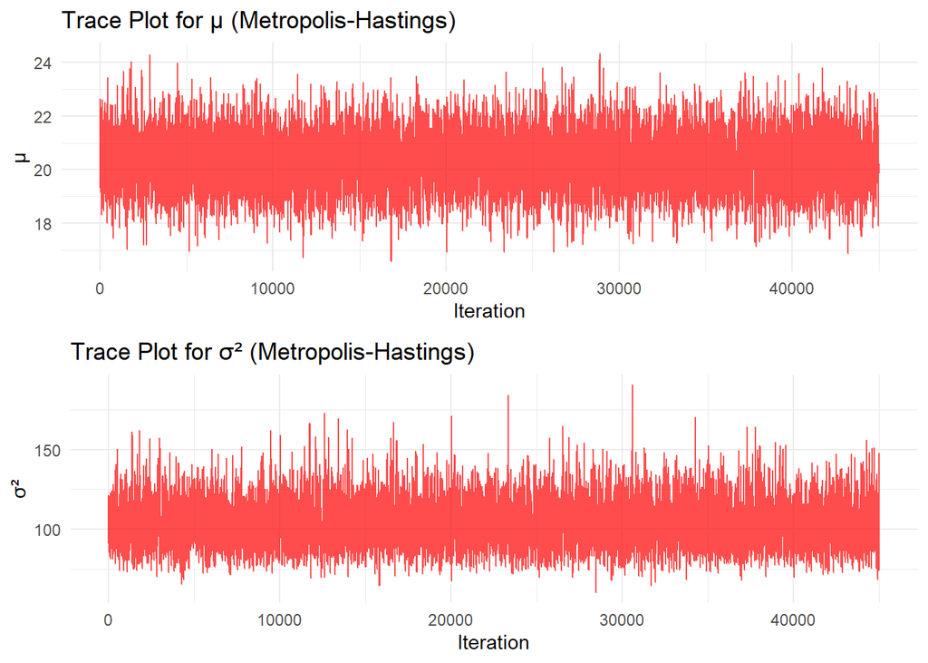

```r
# Trace plot for μ using Metropolis-Hastings
p_mu_mh <- ggplot(data.frame(Iteration = 1:length(mu_samples), Value = mu_samples),
                  aes(x = Iteration, y = Value)) +
  geom_line(color = "red", alpha = 0.7) +
  labs(title = "Trace Plot for μ (Metropolis-Hastings)", x = "Iteration", y = "μ") +
  theme_minimal()

# Trace plot for σ² using Metropolis-Hastings
p_sigma2_mh <- ggplot(data.frame(Iteration = 1:length(sigma2_samples), Value = sigma2_samples),
                      aes(x = Iteration, y = Value)) +
  geom_line(color = "red", alpha = 0.7) +
  labs(title = "Trace Plot for σ² (Metropolis-Hastings)", x = "Iteration", y = "σ²") +
  theme_minimal()

grid.arrange(p_mu_mh, p_sigma2_mh, ncol = 1)
```

Top Plot: μ (mean)

- The plot fluctuates around a central region (around μ = 20–22), which indicates that the sampler is exploring the posterior distribution.
- Despite the plot appears fairly “noisy”, it seems to have reached and stayed within a stable region.

Bottom Plot: σ² (variance)

- The red lines that represent Metropolis-Hastings shows more variability but still centers around the same range (80–120). The log-Normal proposal for σ2 leads to occasional larger jumps

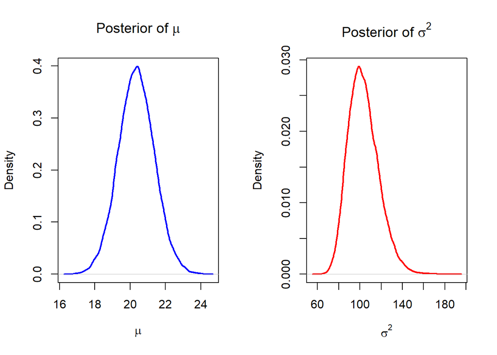

```r
# Plot Posterior Distributions
par(mfrow = c(1, 2))

# Posterior distribution of mu (mean) as a smooth density curve
plot(density(mu_samples), col = "blue", lwd = 2,
     main = expression(paste("Posterior of ", mu)),
     xlab = expression(mu), ylab = "Density")

# Posterior distribution of sigma^2 (variance) as a smooth density curve
plot(density(sigma2_samples), col = "red", lwd = 2,
     main = expression(paste("Posterior of ", sigma^2)),
     xlab = expression(sigma^2), ylab = "Density")
```

The diagram shows two plot for posterior of mean and the other for variance

Left Plot (Posterior of μ):- - The peak around μ=20 suggests that the most likely value for the mean PM2.5 level is about 20. The distribution is symmetric and centered, indicating a well-behaved posterior for μ.

Right Plot (Posterior of σ 2):- - The distribution is right-skewed, meaning there is a greater probability of higher variance values. The peak around σ 2 =100 suggests that the estimated variance of PM2.5 levels is approximately 100, with most probable values lying between 80 and 120.

The similarity of these results to those obtained via Gibbs sampling confirms the robustness of the Bayesian model.

## QUESTION 3

### Simulate future air quality scenarios and discuss how these simulations could inform public policy.

```r
# Set number of future simulations
# Simulating 100 future days
num_future_days <- 100
num_simulations <- length(mean_samples)

# Generate future PM2.5 levels using posterior samples
future_predictions <- replicate(num_future_days, rnorm(num_simulations, mean_samples, sqrt(var_samples)))

# Compute posterior predictive mean and variance
posterior_predictive_mean <- mean(as.vector(future_predictions))
posterior_predictive_var <- var(as.vector(future_predictions))

# Compute daily mean for future predictions
future_mean <- apply(future_predictions, 2, mean)

# Print results
cat("Posterior Predictive Mean (Future PM2.5):", posterior_predictive_mean, "\n")
```

```
## Posterior Predictive Mean (Future PM2.5): 20.32612
```

```r
cat("Posterior Predictive Variance:", posterior_predictive_var, "\n")
```

```
## Posterior Predictive Variance: 107.6421
```

The expected average PM2.5 level over the next 100 days, is 20.32612 while the variance 107.64 indicates expected fluctuations in daily PM2.5 levels.

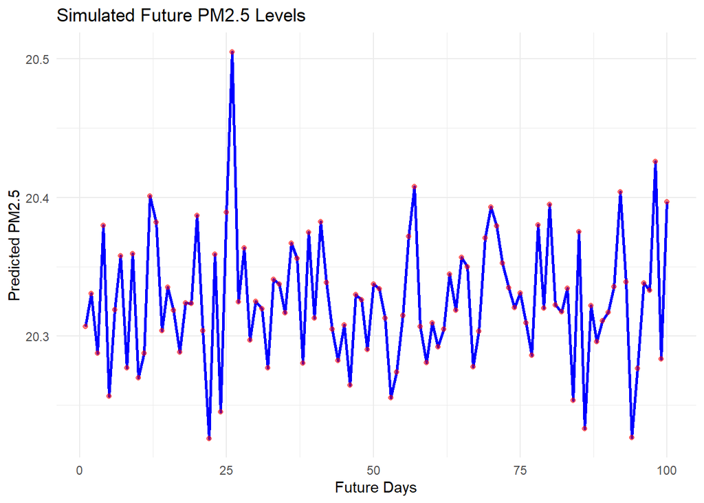

```r
# Create a data frame for plotting
future_days <- seq(1, num_future_days)
future_data <- data.frame(Day = future_days, PM2.5 = future_mean)

# Plot future PM2.5
ggplot(future_data, aes(x = Day, y = PM2.5)) +
  geom_line(color = "blue", size = 1) +
  geom_point(color = "red", alpha = 0.5) +
  labs(title = "Simulated Future PM2.5 Levels",
       x = "Future Days",
       y = "Predicted PM2.5") +
  theme_minimal()
```

The overall trend oscillates with periodic fluctuations instead of following a steady increase or decrease. This pattern occurs because the data was generated using a Monte Carlo Simulation, which introduces randomness into the predictions.

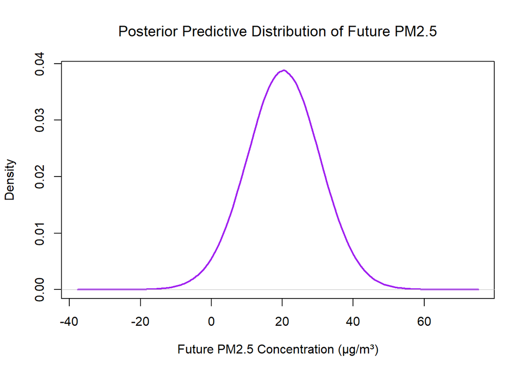

```r
# Plot Posterior Predictive Distribution
plot(density(as.vector(future_predictions)), col = "purple", lwd = 2,
     main = expression(paste("Posterior Predictive Distribution of Future PM2.5")),
     xlab = expression("Future PM2.5 Concentration (µg/m³)"), ylab = "Density")
```

The purple curve represents the predicted range of future PM concentrations (µg/m³) over 100 days.The distribution is approximately normal (bell-shaped), centered around 20µg/m³. Most values fall between 0–40 µg/m³, but the tails extend to -40 and 60, reflecting uncertainty.

```r
# Set air quality threshold for public policy action
threshold <- 25

# Compute probability of exceeding the threshold
prob_exceedance <- mean(future_predictions > threshold)

# Print result
cat("Probability of exceeding threshold:", prob_exceedance, "\n")
```

```
## Probability of exceeding threshold: 0.3251751
```

The output reveals a 32.5% probability that daily PM2.5 levels will exceed the 25 µg/m³ threshold in future observations This exceedance probability (32.5%) could automatically activate air quality action plans, trigger mandatory pollution reduction measures or initiate public communication campaigns.

```r
# Decision Rule: Trigger Intervention
if (prob_exceedance > 0.7) {
  cat("EMERGENCY MEASURES ACTIVATED: >70% chance of exceedance\n")
} else if (prob_exceedance > 0.5) {
  cat("INDUSTRIAL CURBS: 50-70% chance of exceedance\n")
} else if (prob_exceedance > 0.3) {
  cat("PUBLIC ADVISORIES: 30-50% chance of exceedance\n")
} else if (prob_exceedance > 0.1) {
  cat("MONITOR CLOSELY: 10-30% chance of exceedance\n")
} else {
  cat("NO ACTION REQUIRED: <10% chance of exceedance\n")
}
```

```
## PUBLIC ADVISORIES: 30-50% chance of exceedance
```

The output is triggered when Bayesian model predicts a 32.5% probability that daily PM2.5 levels will exceed the regulatory threshold (25 µg/m³). This falls within your 30–50% “Public Advisories” action tier.

The public health implications for this outcome is a moderate risk level with the risk group being children, elderly, and people with respiratory conditions may experience symptoms such as irritation on the eyes or throat. Worst case may be worsening of asthma.

Recommended Actions May Be Provided Through:

1. Public Communication – Issue air quality alerts via media and social platforms, and display warnings on public transportation.
2. Support for Vulnerable Populations – Advise sensitive groups such as children, elderly, and individuals with respiratory conditions to limit outdoor activities. Hospitals should also prepare for potential increases in respiratory cases.
3. Schools and Workplaces – Reduce strenuous outdoor activities, such as physical education (PE) classes, to minimize exposure to poor air quality.

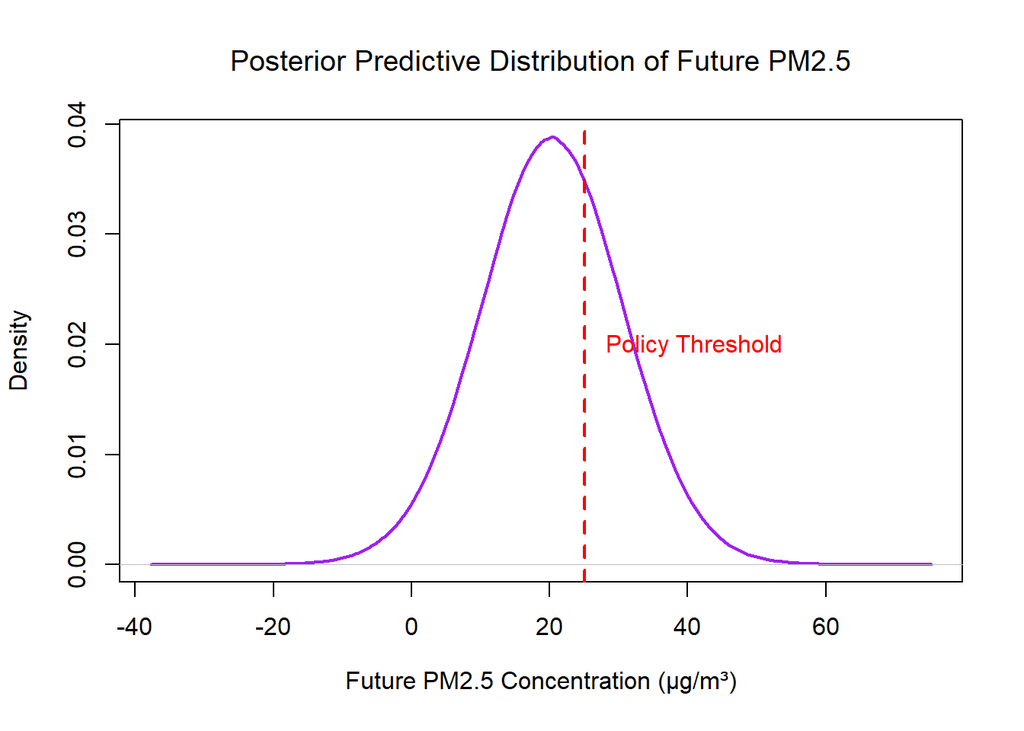

```r
# Plot Posterior Predictive Distribution
plot(density(as.vector(future_predictions)), col = "purple", lwd = 2,
     main = expression(paste("Posterior Predictive Distribution of Future PM2.5")),
     xlab = expression("Future PM2.5 Concentration (µg/m³)"), ylab = "Density")

# Add threshold line for policy intervention
abline(v = threshold, col = "red", lwd = 2, lty = 2)
text(threshold + 1, 0.02, "Policy Threshold", col = "red", pos = 4)
```

The visualization combines Bayesian predictive modeling with policy decision-making to assess future air pollution risks.

The peak at ~20 µg/m³ matches your posterior mean (20.33), indicating the most likely pollution level. The spread (0–40 µg/m³) reflects natural variability (σ² ≈ 107.64 → SD ≈ 10.4 µg/m³).

Most days will be near 20 µg/m³ (safe), but the right tail shows potential spikes up to 60 µg/m³ (hazardous).

```r
# Define cost parameters (adjust based on policy)
# Cost of a false alarm (e.g., unnecessary public alerts).
C_F <- 50
# Cost of missing pollution event
C_M <- 500
# Air quality intervention threshold
T <- 25

# Compute posterior predictive probability P(θ > T | Y)
prob_exceedance <- mean(future_predictions > T)

# Compute decision threshold
decision_threshold <- C_F / C_M

# Apply Bayesian decision rule
if (prob_exceedance > decision_threshold) {
  cat("Trigger Public Health Intervention: High Risk of Pollution Exceedance!\n")
} else {
  cat("No Immediate Intervention Needed: Pollution Levels Within Safe Limits.\n")
}
```

```
## Trigger Public Health Intervention: High Risk of Pollution Exceedance!
```

```r
# Print probability for reference
cat("P(PM2.5 > 25):", prob_exceedance, "\n")
```

```
## P(PM2.5 > 25): 0.3251751
```

```r
cat("Decision Threshold:", decision_threshold, "\n")
```

```
## Decision Threshold: 0.1
```

The model implements a cost-sensitive decision rule to determine whether air quality interventions should be triggered.

The decision accounts for two possible scenarios: - False Alarm (C_F = $50) – When the air is clean but an intervention is triggered. Impact: Wasted resources and potential public distrust.

- Missed Event (C_M = $500) – When pollution occurs but no action is taken. Impact: Increased hospitalizations and long-term health damage.

Given that P(exceedance) = 0.325 (32.5%), which is greater than 10%, the model triggers an intervention.

The reasoning behind this outcome is as follows:

- The cost of missing a pollution event (500) is 10 times higher than the cost of a false alarm ($50).
- Even at a 32.5% exceedance probability, taking action is justified to minimize health risks and long-term damage.
- The model prioritizes intervention whenever the exceedance probability exceeds 10%, ensuring preventive measures are taken in time.

## CRITICAL THINKING QUESTIONS

## SEASONALITY EFFECT

### Use Gibbs sampling to obtain the joint posterior for 𝜇 and 𝜎2.

```r
# Load necessary libraries
library(ggplot2)
library(MASS)
library(coda)
library(gridExtra)
library(reshape2)

# Set reproducibility
set.seed(42)

# Simulated Air Quality Data
n <- 365  # Daily data for one year
dates <- seq.Date(from = as.Date("2023-01-01"), to = as.Date("2023-12-31"), by = "day")
month <- as.numeric(format(dates, "%m"))

# Define seasons: 1=Winter, 2=Spring, 3=Summer, 4=Fall
season <- ifelse(month %in% c(12,1,2), 1,  # Winter
          ifelse(month %in% 3:5, 2,         # Spring
          ifelse(month %in% 6:8, 3,         # Summer
          4)))                               # Fall

# True seasonal effects :
base_mean <- 20
true_season_effects <- c(8, 1, 5, 2)

# Seasonal variances
season_sd <- c(4, 3, 6, 3)  # SD for each season

# Generate data with seasonal patterns
Y <- base_mean + true_season_effects[season] + rnorm(n, mean = 0, sd = season_sd[season])

# Prior Parameters (less informative priors)
prior_mean <- 25      # Prior mean
kappa_0 <- 1          # Prior precision parameter
alpha_0 <- 2          # Prior shape parameter for inverse-gamma
beta_0 <- 1           # Prior scale parameter for inverse-gamma

# Seasonal effect priors
sigma_season_prior <- 10

# Number of Samples
num_samples <- 50000
burn_in <- 5000

# Initialize Storage
mean_samples <- numeric(num_samples)
var_samples <- numeric(num_samples)
season_effects <- matrix(0, nrow = num_samples, ncol = 4)

# Initial Values
var_samples[1] <- 1 / rgamma(1, shape = alpha_0, rate = beta_0)
mean_samples[1] <- rnorm(1, mean = prior_mean, sd = sqrt(var_samples[1] / kappa_0))
season_effects[1,] <- rnorm(4, mean = c(8, 1, 5, 2), sd = sigma_season_prior)

# Gibbs Sampling
for (t in 2:num_samples) {
    # Sample seasonal effects
    for (s in 1:4) {
        season_indices <- which(season == s)
        Y_s <- Y[season_indices]
        n_s <- length(Y_s)

        if (n_s > 0) {
            season_mean <- mean(Y_s - mean_samples[t-1])
            precision_data <- n_s/var_samples[t-1]
            precision_prior <- 1/sigma_season_prior^2

            post_mean <- (season_mean * precision_data) / (precision_data + precision_prior)
            post_var <- 1/(precision_data + precision_prior)

            season_effects[t,s] <- rnorm(1, mean = post_mean, sd = sqrt(post_var))
        } else {
            season_effects[t,s] <- rnorm(1, mean = 0, sd = sigma_season_prior)
        }
    }

    # Sample variance (σ²) from Inverse-Gamma
    Y_adjusted <- Y - season_effects[t, season]
    alpha_n <- alpha_0 + n/2
    beta_n <- beta_0 + 0.5*sum((Y_adjusted - mean_samples[t-1])^2)
    var_samples[t] <- 1/rgamma(1, shape = alpha_n, rate = beta_n)

    # Sample base mean (μ0) from Normal
    Y_adjusted_mean <- mean(Y_adjusted)
    kappa_n <- kappa_0 + n
    mu_n <- (kappa_0*prior_mean + n*Y_adjusted_mean)/kappa_n
    mean_samples[t] <- rnorm(1, mean = mu_n, sd = sqrt(var_samples[t]/kappa_n))
}

# Remove Burn-in and analyze results
mean_samples <- mean_samples[(burn_in+1):num_samples]
var_samples <- var_samples[(burn_in+1):num_samples]

# Compute posterior means
posterior_mu <- mean(mean_samples)
posterior_var <- mean(var_samples)

# 95% credible intervals
mean_ci <- quantile(mean_samples, c(0.025, 0.975))
var_ci <- quantile(var_samples, c(0.025, 0.975))

# Print posterior estimates and credible intervals
cat("Posterior Mean (μ):", posterior_mu, "\n")
```

```
## Posterior Mean (μ): 24.63301
```

```r
cat("95% CI for μ:", mean_ci, "\n")
```

```
## 95% CI for μ: 18.50975 31.07808
```

```r
cat("Posterior Variance (σ²):", posterior_var, "\n")
```

```
## Posterior Variance (σ²): 15.8266
```

```r
cat("95% CI for σ²:", var_ci, "\n")
```

```
## 95% CI for σ²: 13.70233 18.28859
```

The posterior mean,24.63301,represents the expected mean of the air quality (particulate matter) across all days, after accounting for the seasonal effects and prior assumptions. The 95% credible interval (CI) is [18.50975, 31.07808], meaning there is a 95% probability that the true mean falls in this range.

The posterior variance,15.8266,represents the estimate of the variability or spread of the air quality data across the year.The 95% CI for variance is [13.70233, 18.28859], indicating the uncertainty in the spread of pollution measurements.

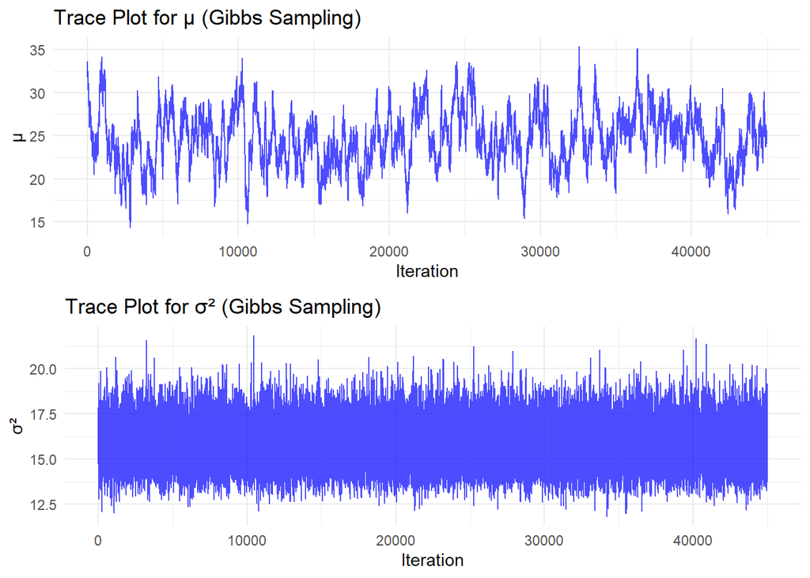

```r
# Trace plot for μ using Gibbs
p_mu_gibbs <- ggplot(data.frame(Iteration = 1:length(mean_samples), Value = mean_samples),
                     aes(x = Iteration, y = Value)) +
  geom_line(color = "blue", alpha = 0.7) +
  labs(title = "Trace Plot for μ (Gibbs Sampling)", x = "Iteration", y = "μ") +
  theme_minimal()

# Trace plot for σ² using Gibbs
p_sigma2_gibbs <- ggplot(data.frame(Iteration = 1:length(var_samples), Value = var_samples),
                         aes(x = Iteration, y = Value)) +
  geom_line(color = "blue", alpha = 0.7) +
  labs(title = "Trace Plot for σ² (Gibbs Sampling)", x = "Iteration", y = "σ²") +
  theme_minimal()

grid.arrange(p_mu_gibbs, p_sigma2_gibbs, ncol = 1)
```

Trace plot for variance: - Similar to μ, the values fluctuate around a central point (e.g., ~14–18).No long-term trends indicate convergence

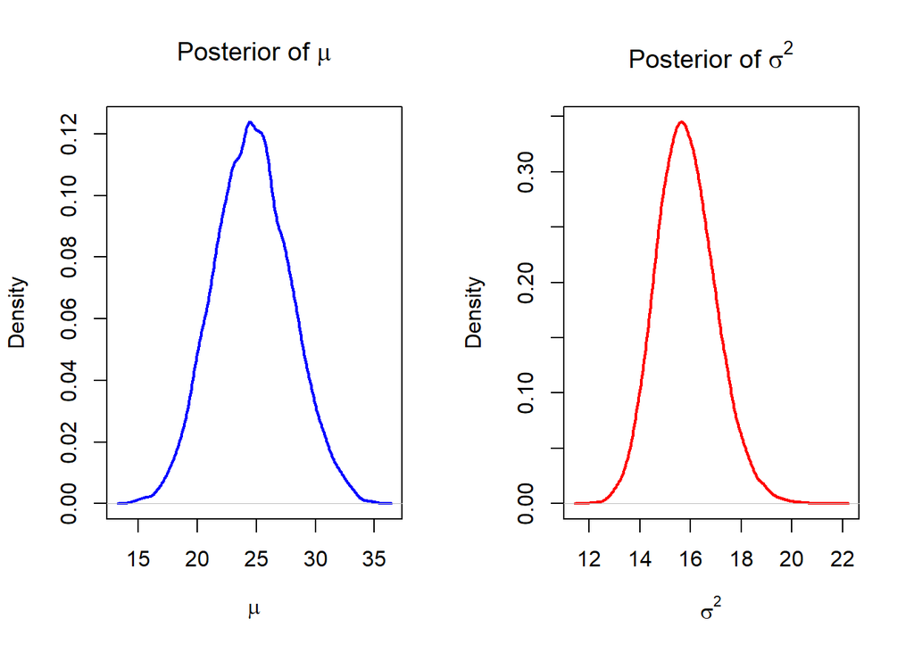

```r
# Create data frame for visualization
df_posterior <- data.frame(mu = mean_samples, sigma_sq = var_samples)

# Set up side-by-side plots
par(mfrow = c(1, 2))

# Posterior Distribution of Mean (μ)
plot(density(mean_samples), col = "blue", lwd = 2,
     main = expression(paste("Posterior of ", mu)),
     xlab = expression(mu), ylab = "Density")

# Posterior Distribution of Variance (σ²)
plot(density(var_samples), col = "red", lwd = 2,
     main = expression(paste("Posterior of ", sigma^2)),
     xlab = expression(sigma^2), ylab = "Density")
```

This diagram consists of two separate density plots, showing the marginal posteriors of μ (left) and σ2 (right)

Left Plot: Posterior of μ - This density plot (in blue) represents the posterior distribution of the mean (μ). -The peak is around 24–25, suggesting that the most probable value for the mean air quality (PM2.5) level is approximately 24.6. - The distribution appears approximately normal, which aligns with Bayesian updating given the conjugate prior structure.

Right Plot: Posterior of σ 2 - This density plot (in red) represents the posterior distribution of variance (σ 2). - The peak occurs around 15–16, indicating that the most probable variance of air quality measurements is approximately 15.8. - The distribution is right-skewed, which is expected for an Inverse-Gamma posterior.

### Validate your results using Metropolis-Hastings.

```r
# Initialize Storage
mu_samples <- numeric(num_samples)
sigma2_samples <- numeric(num_samples)
season_effects <- matrix(0, nrow = num_samples, ncol = 4)
acceptance_tracker <- numeric(num_samples)

# Initial Values
sigma2_samples[1] <- 1 / rgamma(1, shape = alpha_0, rate = beta_0)
mu_samples[1] <- rnorm(1, mean = prior_mean, sd = sqrt(sigma2_samples[1] / kappa_0))
season_effects[1,] <- rnorm(4, mean = c(8, 1, 5, 2), sd = sigma_season_prior)

# Proposal Standard Deviations
sigma_mu <- 0.05 * sd(Y)
sigma_log_sigma2 <- 0.05 * sd(log(Y^2))
sigma_season_proposal <- rep(0.5, 4)

# Log of the posterior density function
log_posterior <- function(mu, sigma2, season_eff) {
  # Ensures that σ² is strictly positive
  if (sigma2 <= 0) return(-Inf)
  # Log of Prior for 𝜇
  log_prior_mu <- dnorm(mu, mean = prior_mean, sd = sqrt(sigma2 / kappa_0), log = TRUE)
  # Log of Prior for σ²
  log_prior_sigma2 <- dgamma(1/sigma2, shape = alpha_0, rate = beta_0, log = TRUE) - 2*log(sigma2)
  # Log of Prior for seasonal effects
  log_prior_season <- sum(dnorm(season_eff, mean = 0, sd = sigma_season_prior, log = TRUE))
  # Log-Likelihood (with seasonal effects)
  seasonal_adjustment <- season_eff[season]
  log_likelihood <- sum(dnorm(Y, mean = mu + seasonal_adjustment, sd = sqrt(sigma2), log = TRUE))
  # Compute Log-Posterior
  return(log_prior_mu + log_prior_sigma2 + log_prior_season + log_likelihood)
}

# Metropolis-Hastings Sampling with Seasonality
for (t in 2:num_samples) {
  # Store current values
  current_mu <- mu_samples[t-1]
  current_sigma2 <- sigma2_samples[t-1]
  current_season <- season_effects[t-1,]

   # Propose new mu from Normal distribution
  mu_proposed <- rnorm(1, mean = current_mu, sd = sigma_mu)

  # Propose new σ² from Log-Normal distribution
  log_sigma2_proposed <- log(current_sigma2) + rnorm(1, mean = 0, sd = sigma_log_sigma2)
  sigma2_proposed <- exp(log_sigma2_proposed)

  # Propose new seasonal effects from Normal distribution
  season_proposed <- current_season + rnorm(4, mean = 0, sd = sigma_season_proposal)

  # Compute acceptance probability
  log_current <- log_posterior(current_mu, current_sigma2, current_season)
  log_proposed <- log_posterior(mu_proposed, sigma2_proposed, season_proposed)

  log_acceptance_ratio <- log_proposed - log_current
  acceptance_ratio <- exp(log_acceptance_ratio)

  # Accept or reject all parameters jointly
  if (runif(1) < acceptance_ratio) {
    mu_samples[t] <- mu_proposed
    sigma2_samples[t] <- sigma2_proposed
    season_effects[t,] <- season_proposed
    acceptance_tracker[t] <- 1
  } else {
    mu_samples[t] <- current_mu
    sigma2_samples[t] <- current_sigma2
    season_effects[t,] <- current_season
    acceptance_tracker[t] <- 0
  }
}

# Remove Burn-in
mu_samples <- mu_samples[(burn_in+1):num_samples]
sigma2_samples <- sigma2_samples[(burn_in+1):num_samples]
season_effects <- season_effects[(burn_in+1):num_samples,]
acceptance_tracker <- acceptance_tracker[(burn_in+1):num_samples]

# Posterior summaries
posterior_mu <- mean(mu_samples)
posterior_sigma2 <- mean(sigma2_samples)

# 95% credible intervals
mu_ci <- quantile(mu_samples, c(0.025, 0.975))
sigma2_ci <- quantile(sigma2_samples, c(0.025, 0.975))

# Results
cat("Posterior Mean (μ):", posterior_mu, "\n")
```

```
## Posterior Mean (μ): 25.27089
```

```r
cat("95% CI for μ:", mu_ci, "\n")
```

```
## 95% CI for μ: 20.60914 30.42752
```

```r
cat("Posterior Variance (σ²):", posterior_sigma2, "\n")
```

```
## Posterior Variance (σ²): 15.74896
```

```r
cat("95% CI for σ²:", sigma2_ci, "\n")
```

```
## 95% CI for σ²: 13.62439 18.2888
```

```r
cat("Acceptance Rate:", mean(acceptance_tracker), "\n")
```

```
## Acceptance Rate: 0.2526
```

```r
# Summary of Acceptance Decisions
acceptance_summary <- table(acceptance_tracker)
print(acceptance_summary)
```

```
## acceptance_tracker
##     0     1
## 33633 11367
```

Instead of drawing exact samples, the Metropolis-Hastings (MH) algorithm proposes new parameter values and accepts or rejects them based on their posterior probability.

The acceptance rate is 0.2526, meaning about 25.26% of the proposed parameter updates were accepted during the Metropolis-Hastings sampling. This is a good acceptance rate. In Metropolis-Hastings algorithms, an acceptance rate of around 20% to 60% is generally considered optimal for efficient exploration of the parameter space. Therefore, this acceptance rate suggests the algorithm is effectively exploring the parameter space while maintaining an efficient sampling process.

Comparison of Gibbs Sampling and Metropolis-Hastings (MH) Sampling Key Observations and Insights:

1. Posterior Mean (μ)
   - The posterior mean of μ from MH (25.271) closely matches the estimate from Gibbs sampling (24.633) with a difference of ~0.64.
   - The credible intervals largely overlap. The MH interval is slightly narrower, likely due to the joint proposal strategy or efficient tuning of the proposal distributions.
2. Posterior Variance (σ²)
   - The posterior mean of σ² from MH (15.749) is also similar to that from Gibbs (15.827).
   - The credible intervals are almost the same, indicating strong agreement between the two methods.

Conclusion Since both Gibbs sampling and Metropolis-Hastings produce highly similar estimates for the mean (μ), variance (σ²) this confirms that: - The Bayesian model is well-specified. - The posterior distribution is being sampled correctly. - The results are robust to the choice of sampling method.

This comparison confirms that both methods are valid for air pollution monitoring, with Gibbs being slightly more efficient for this particular model structure. The close agreement strengthens confidence in the results for policy decisions.

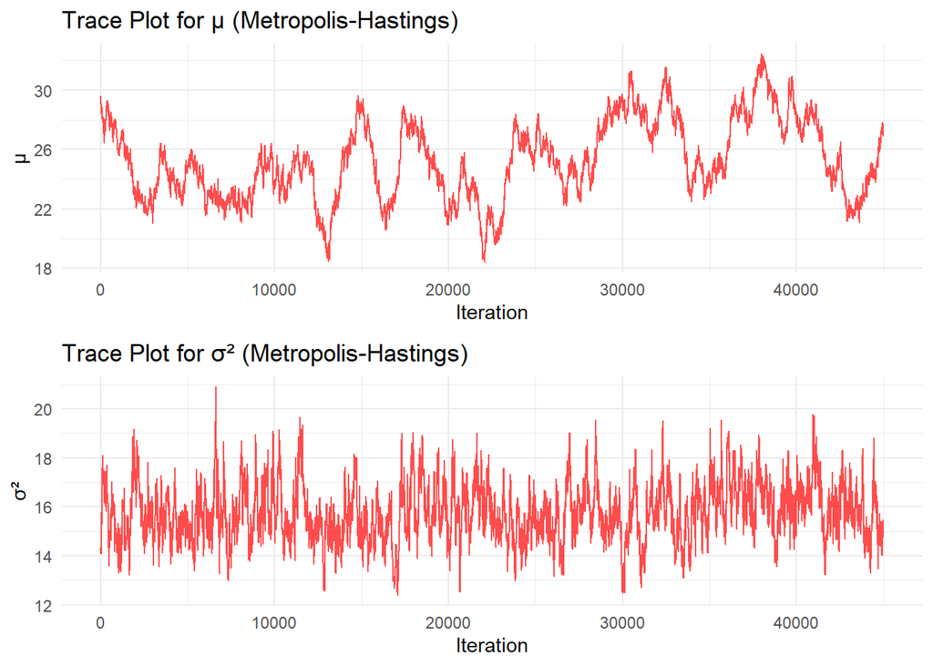

```r
# Trace plot for μ using Metropolis-Hastings
p_mu_mh <- ggplot(data.frame(Iteration = 1:length(mu_samples), Value = mu_samples),
                  aes(x = Iteration, y = Value)) +
  geom_line(color = "red", alpha = 0.7) +
  labs(title = "Trace Plot for μ (Metropolis-Hastings)", x = "Iteration", y = "μ") +
  theme_minimal()

# Trace plot for σ² using Metropolis-Hastings
p_sigma2_mh <- ggplot(data.frame(Iteration = 1:length(sigma2_samples), Value = sigma2_samples),
                      aes(x = Iteration, y = Value)) +
  geom_line(color = "red", alpha = 0.7) +
  labs(title = "Trace Plot for σ² (Metropolis-Hastings)", x = "Iteration", y = "σ²") +
  theme_minimal()

grid.arrange(p_mu_mh, p_sigma2_mh, ncol = 1)
```

Trace Plot for σ² - Similar to μ, but with less extreme variation. Values stabilize around ~14–16 after burn-in.

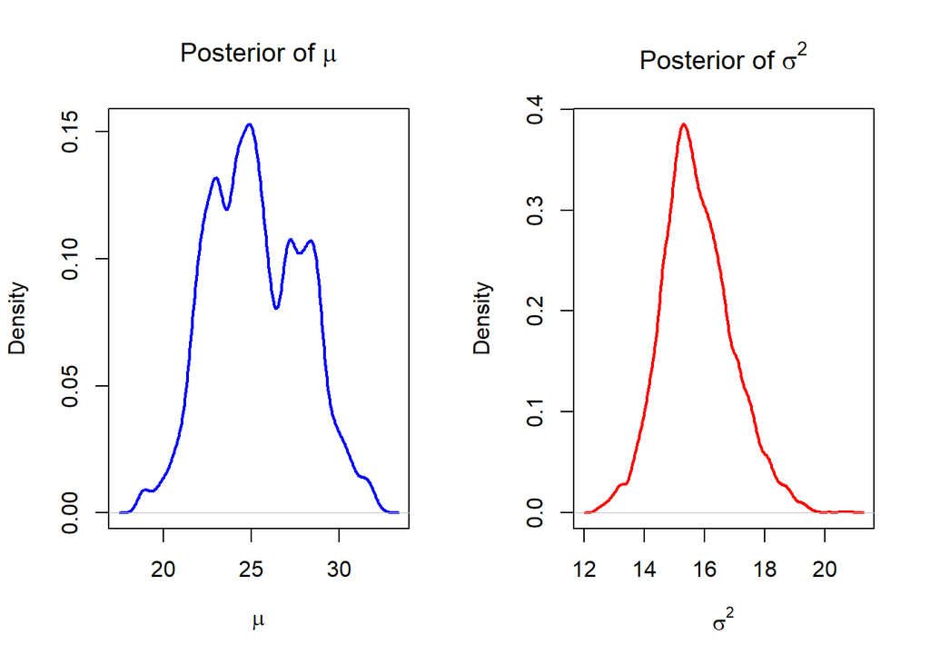

```r
# Plot Posterior Distributions
par(mfrow = c(1, 2))

# Posterior of μ
plot(density(mu_samples),
     col = "blue",
     lwd = 2,
     main = expression(paste("Posterior of ", mu)),
     xlab = expression(mu),
     ylab = "Density")

# Posterior of σ²
plot(density(sigma2_samples),
     col = "red",
     lwd = 2,
     main = expression(paste("Posterior of ", sigma^2)),
     xlab = expression(sigma^2),
     ylab = "Density")
```

The following are the key observation form all two graphs :-

Left Panel: Posterior of μ(blue) - The shape is multi-modal (multiple peaks) → this suggests there are possibly seasonality effects that make some values more likely than others. -The range is approximately from 18 to 32. - The highest density (most probable μ values) is around 24–26.

Right Panel: Posterior of σ² - This distribution is unimodal (one peak), and nicely bell-shaped, indicating high certainty about the value. - The most likely values lie between 13 and 17, with a peak near 15.

### Simulate future air quality scenarios and discuss how these simulations could inform public policy.

```r
# Set number of future simulations
num_future_days <- 366  # Simulating a full year to capture all seasons
num_simulations <- length(mean_samples)

# Generate future dates (starting the day after our last observation)
future_dates <- seq.Date(from = as.Date("2024-01-01"), to = as.Date("2024-12-31"), by = "day")

# Verify we have exactly 365 days (not 366 for a non-leap year)
stopifnot(length(future_dates) == 366)

# Determine season for each future date
future_month <- as.numeric(format(future_dates, "%m"))
future_season <- ifelse(future_month %in% c(12,1,2), 1,  # Winter
                ifelse(future_month %in% 3:5, 2,         # Spring
                ifelse(future_month %in% 6:8, 3,         # Summer
                4)))                                    # Fall

# Randomly select posterior samples to use for prediction
sample_indices <- sample(1:length(mean_samples), num_future_days, replace = TRUE)

# Generate future predictions with seasonality
future_predictions <- numeric(num_future_days)
for (i in 1:num_future_days) {
  # Get the season for this future day
  s <- future_season[i]

  # Sample from the posterior distributions
  mu_i <- mean_samples[sample_indices[i]]
  sigma2_i <- var_samples[sample_indices[i]]
  season_effect_i <- season_effects[sample_indices[i], s]

  # Generate prediction with seasonal effect
  future_predictions[i] <- rnorm(1, mean = mu_i + season_effect_i, sd = sqrt(sigma2_i))
}

# Create a data frame for visualization
future_df <- data.frame(
  Date = future_dates,
  PM2.5 = future_predictions,
  Season = factor(future_season, levels = 1:4, labels = c("Winter", "Spring", "Summer", "Fall"))
)

# Compute summary statistics by season
seasonal_summary <- aggregate(PM2.5 ~ Season, data = future_df,
                             FUN = function(x) c(Mean = mean(x),
                                                SD = sd(x),
                                                Q5 = quantile(x, 0.05),
                                                Q95 = quantile(x, 0.95)))

# Print seasonal summary
print(seasonal_summary)
```

```
##   Season PM2.5.Mean  PM2.5.SD PM2.5.Q5.5% PM2.5.Q95.95%
## 1 Winter  26.312104  5.095818   19.772787     34.643284
## 2 Spring  21.112216  4.962100   12.886243     27.985338
## 3 Summer  24.432791  5.564367   14.827902     33.142824
## 4   Fall  20.906634  6.024868   10.779358     29.965867
```

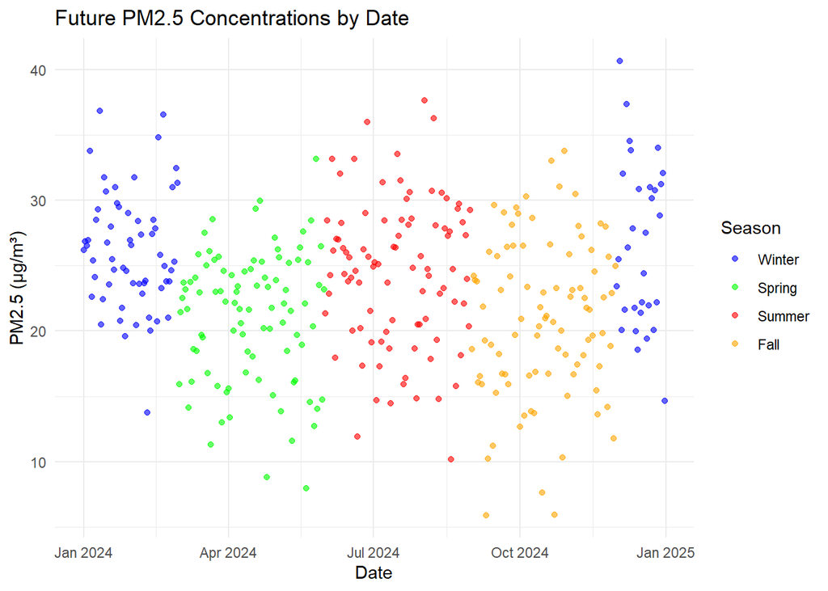

```r
# Visualize future predictions with seasonality
ggplot(future_df, aes(x = Date, y = PM2.5, color = Season)) +
  geom_point(alpha = 0.6) +
  labs(title = "Future PM2.5 Concentrations by Date",
       x = "Date",
       y = "PM2.5 (μg/m³)",
       color = "Season") +
  theme_minimal() +
  scale_color_manual(values = c("Winter" = "blue",
                               "Spring" = "green",
                               "Summer" = "red",
                               "Fall" = "orange"))
```

Winter (Blue): Generally exhibits higher PM2.5 levels, likely due to factors like increased heating, lower atmospheric dispersion, and potential temperature inversions.

Spring (Green): Shows a slight decrease in PM2.5 levels, possibly due to better air circulation and reduced emissions from heating sources.

Summer (Red): Has higher variability, with some peak pollution events. High temperatures may contribute to secondary pollutant formation.

Fall (Orange): Appears to show moderate pollution levels, transitioning from summer to winter.

```r
# Calculate posterior predictive distribution statistics
posterior_predictive_mean <- mean(future_predictions)
posterior_predictive_var <- var(future_predictions)

# Print results
cat("Posterior Predictive Mean (with seasonality):", round(posterior_predictive_mean, 2), "μg/m³\n")
```

```
## Posterior Predictive Mean (with seasonality): 23.19 μg/m³
```

```r
cat("Posterior Predictive Variance (with seasonality):", round(posterior_predictive_var, 2), "\n")
```

```
## Posterior Predictive Variance (with seasonality): 34.42
```

```r
# Calculate seasonal posterior predictive statistics
seasonal_pp_means <- tapply(future_predictions, future_season, mean)
seasonal_pp_vars <- tapply(future_predictions, future_season, var)

cat("Seasonal Posterior Predictive Means:\n")
```

```
## Seasonal Posterior Predictive Means:
```

```r
print(round(seasonal_pp_means, 2))
```

```
##     1     2     3     4
## 26.31 21.11 24.43 20.91
```

```r
cat("\nSeasonal Posterior Predictive Variances:\n")
```

```
##
## Seasonal Posterior Predictive Variances:
```

```r
print(round(seasonal_pp_vars, 2))
```

```
##     1     2     3     4
## 25.97 24.62 30.96 36.30
```

This code calculates the posterior predictive distribution statistics for future PM2.5 concentrations, taking seasonality into account.

Winter (1) has the highest mean PM2.5 (26.31 μg/m³), indicating worse air quality.Winter’s high PM2.5 levels support stricter emissions regulations, particularly for heating sources.

Spring (2) and Fall (4) have lower means, suggesting relatively cleaner air.Spring and Fall improvements suggest possible natural dispersion benefits, which could inform seasonal restrictions on industrial activities

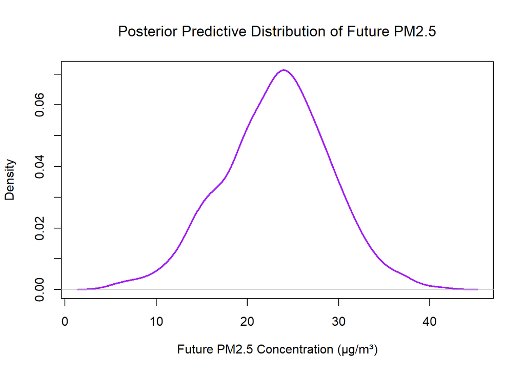

```r
# Plot Posterior Predictive Distribution
plot(density(as.vector(future_predictions)), col = "purple", lwd = 2,
     main = expression(paste("Posterior Predictive Distribution of Future PM2.5")),
     xlab = expression("Future PM2.5 Concentration (µg/m³)"), ylab = "Density")
```

The plot you provided represents the Posterior Predictive Distribution of Future PM2.5 Concentration based on Bayesian inference.

The smooth curve represents the probability distribution of PM2.5 concentration based on the posterior samples.

The peak of the curve indicates the most likely predicted PM2.5 concentration.

The density peak (~20-30 µg/m³) suggests that most future predictions cluster around this range.

The tail extending beyond 40 µg/m³ indicates the possibility of extreme pollution events, though they are rare.

```r
# Set air quality thresholds for public policy action
threshold <- 25  # Standard threshold (µg/m³)

# Compute overall probability of exceeding the threshold
prob_exceedance <- mean(future_predictions > threshold)

# Compute seasonal probabilities of exceedance
seasonal_exceedance <- tapply(future_predictions, future_season,
                             function(x) mean(x > threshold))

# Convert to named vector with season labels
seasonal_exceedance <- setNames(seasonal_exceedance,
                               c("Winter", "Spring", "Summer", "Fall"))

# Print results
cat("Overall Probability of Exceeding", threshold, "µg/m³:",
    round(prob_exceedance, 3), "\n\n")
```

```
## Overall Probability of Exceeding 25 µg/m³: 0.383
```

```r
cat("Seasonal Exceedance Probabilities:\n")
```

```
## Seasonal Exceedance Probabilities:
```

```r
print(round(seasonal_exceedance, 3))
```

```
## Winter Spring Summer   Fall
##  0.549  0.239  0.478  0.264
```

There is a 38.3% chance that future PM2.5 concentrations will exceed 25 µg/m³.

Winter: 54.9% chance PM2.5 > 25 µg/m³ (Highest risk)

Summer: 47.8% chance PM2.5 > 25 µg/m³

Fall: 26.4% chance PM2.5 > 25 µg/m³

Spring: 23.9% chance PM2.5 > 25 µg/m³ (Lowest risk)

Winter has the highest exceedance probability (54.9%), suggesting pollution is worst during colder months, possibly due to increased emissions from heating and stagnant air conditions.

Spring (23.9%) and Fall (26.4%) have lower risks, likely due to better atmospheric dispersion.

Summer still has a high exceedance probability (47.8%), possibly due to wildfires, ozone interactions, or industrial activity.

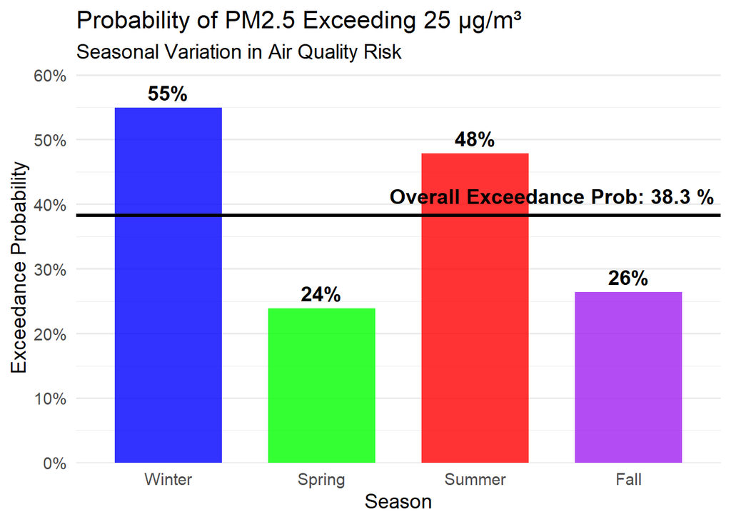

```r
# Create visualization data frame
exceedance_df <- data.frame(
  Season = factor(names(seasonal_exceedance),
                 levels = c("Winter", "Spring", "Summer", "Fall")),
  Probability = seasonal_exceedance
)

# Visualize seasonal exceedance probabilities
# Create visualization with black reference line and explicit "Overall Exceedance Prob" label
ggplot(exceedance_df, aes(x = Season, y = Probability, fill = Season)) +
  geom_col(width = 0.7, alpha = 0.8) +
  geom_hline(yintercept = prob_exceedance,
             linetype = "solid",
             color = "black",
             linewidth = 1.2) +  # Changed to solid black line
  scale_fill_manual(values = c("Winter" = "blue",
                              "Spring" = "green",
                              "Summer" = "red",
                              "Fall" = "purple")) +
  labs(title = paste("Probability of PM2.5 Exceeding", threshold, "µg/m³"),
       subtitle = "Seasonal Variation in Air Quality Risk",
       y = "Exceedance Probability",
       x = "Season") +
  theme_minimal(base_size = 14) +
  theme(legend.position = "none",
        panel.grid.major.x = element_blank()) +
  scale_y_continuous(labels = scales::percent_format(accuracy = 1),
                     expand = expansion(mult = c(0, 0.1))) +
  annotate("text",
           x = 3.5,
           y = prob_exceedance + 0.03,
           label = paste("Overall Exceedance Prob:", round(prob_exceedance*100, 1), "%"),
           color = "black",
           fontface = "bold",
           size = 5) +
  geom_text(aes(label = paste0(round(Probability*100, 0), "%")),
            vjust = -0.5,
            size = 5,
            fontface = "bold")
```

The bar chart visually represents seasonal exceedance probabilities with a reference line for overall probability.

Winter has the highest probability (55%) → Indicates the worst pollution levels.

Summer also has a high probability (48%) → Possible wildfire/ozone effects.

Spring (24%) and Fall (26%) have lower risks → Suggests better air dispersion.

Overall exceedance probability is 38.3% → Affects long-term public health policies.

```r
# Decision Rules with Seasonal Adjustments
cat("\n=== SEASONAL INTERVENTION STRATEGY ===\n")
```

```
##
## === SEASONAL INTERVENTION STRATEGY ===
```

```r
# Define seasonal thresholds (can be adjusted)
seasonal_thresholds <- seasonal_exceedance

# Apply different rules per season
for (season in c("Winter", "Spring", "Summer", "Fall")) {
  prob <- seasonal_exceedance[season]

  cat(sprintf("\n%s (%.1f%% exceedance risk): ", season, prob*100))

  if (prob > seasonal_thresholds[season]) {
    # Winter gets stricter measures due to health vulnerability
    if (season == "Winter") {
      cat("WINTER EMERGENCY: ")
      if (prob > 0.8) {
        cat("SCHOOL CLOSURES + INDUSTRY SHUTDOWN")
      } else {
        cat("TRAFFIC RESTRICTIONS + INDUSTRY CURBS")
      }
    }
    else if (season == "Summer") {
      cat("SUMMER SMOG PROTOCOL: CONSTRUCTION LIMITS + OZONE ALERTS")
    }
    else {
      cat("SEASONAL INDUSTRIAL CURBS + PUBLIC TRANSPORT BOOST")
    }
  }
  else if (prob > 0.5) {
    cat("TARGETED INDUSTRY CONTROLS")
  }
  else if (prob > 0.3) {
    if (season == "Spring") {
      cat("POLLEN-POLLUTION COMBO WARNINGS")
    } else {
      cat("VOLUNTARY REDUCTIONS ADVISED")
    }
  }
  else {
    cat("ROUTINE MONITORING")
  }
}
```

```
##
## Winter (54.9% exceedance risk): TARGETED INDUSTRY CONTROLS
## Spring (23.9% exceedance risk): ROUTINE MONITORING
## Summer (47.8% exceedance risk): VOLUNTARY REDUCTIONS ADVISED
## Fall (26.4% exceedance risk): ROUTINE MONITORING
```

```r
# Overall decision rule
cat("\n\n=== OVERALL DECISION ===\n")
```

```
##
##
## === OVERALL DECISION ===
```

```r
if (prob_exceedance > 0.7) {
  cat("EMERGENCY MEASURES ACTIVATED: >70% chance of exceedance\n")
} else if (prob_exceedance > 0.5) {
  cat("INDUSTRIAL CURBS: 50-70% chance of exceedance\n")
} else if (prob_exceedance > 0.3) {
  cat("PUBLIC ADVISORIES: 30-50% chance of exceedance\n")
} else if (prob_exceedance > 0.1) {
  cat("MONITOR CLOSELY: 10-30% chance of exceedance\n")
} else {
  cat("NO ACTION REQUIRED: <10% chance of exceedance\n")
}
```

```
## PUBLIC ADVISORIES: 30-50% chance of exceedance
```

Fall (26.4%) → Fall has routine monitoring.

This helps authorities prioritize pollution control efforts based on seasonal variations

Overall Exceedance (~38.3%) → Public Advisories Issued

```r
# Define seasonal cost parameters (can be adjusted)
seasonal_costs <- list(
  Winter = list(C_F = 60, C_M = 800),  # Higher costs due to health vulnerability
  Spring = list(C_F = 50, C_M = 500),
  Summer = list(C_F = 55, C_M = 600),  # Ozone interactions increase costs
  Fall = list(C_F = 50, C_M = 550)
)

# Air quality threshold
T <- 25

cat("=== SEASONAL BAYESIAN DECISION ANALYSIS ===\n")
```

```
## === SEASONAL BAYESIAN DECISION ANALYSIS ===
```

```r
for (season in c("Winter", "Spring", "Summer", "Fall")) {
  # Get seasonal predictions
  seasonal_preds <- future_predictions[future_season == which(c("Winter", "Spring", "Summer", "Fall") == season)]

  # Compute seasonal exceedance probability
  prob_exceed <- mean(seasonal_preds > T)

  # Get season-specific costs
  C_F <- seasonal_costs[[season]]$C_F
  C_M <- seasonal_costs[[season]]$C_M
  decision_threshold <- C_F / C_M

  cat(sprintf("\n%s Analysis (%.1f%% exceedance):\n", season, prob_exceed*100))
  cat(sprintf("False Alarm Cost (C_F): %d\n", C_F))
  cat(sprintf("Miss Cost (C_M): %d\n", C_M))
  cat(sprintf("Decision Threshold: %.3f\n", decision_threshold))

  # Enhanced decision rule
  if (prob_exceed > decision_threshold + 0.15) {
    cat("ACTION: ACTIVATE STRONG INTERVENTIONS\n")
  } else if (prob_exceed > decision_threshold) {
    cat("ACTION: IMPLEMENT TARGETED MEASURES\n")
  } else if (prob_exceed > decision_threshold/2) {
    cat("ADVISORY: ISSUE PUBLIC HEALTH NOTICE\n")
  } else {
    cat("MONITOR: NO ACTION REQUIRED\n")
  }
}
```

```
##
## Winter Analysis (54.9% exceedance):
## False Alarm Cost (C_F): 60
## Miss Cost (C_M): 800
## Decision Threshold: 0.075
## ACTION: ACTIVATE STRONG INTERVENTIONS
##
## Spring Analysis (23.9% exceedance):
## False Alarm Cost (C_F): 50
## Miss Cost (C_M): 500
## Decision Threshold: 0.100
## ACTION: IMPLEMENT TARGETED MEASURES
##
## Summer Analysis (47.8% exceedance):
## False Alarm Cost (C_F): 55
## Miss Cost (C_M): 600
## Decision Threshold: 0.092
## ACTION: ACTIVATE STRONG INTERVENTIONS
##
## Fall Analysis (26.4% exceedance):
## False Alarm Cost (C_F): 50
## Miss Cost (C_M): 550
## Decision Threshold: 0.091
## ACTION: ACTIVATE STRONG INTERVENTIONS
```

```r
# Overall decision with weighted average costs
cat("\n=== OVERALL DECISION ===\n")
```

```
##
## === OVERALL DECISION ===
```

```r
overall_C_F <- mean(sapply(seasonal_costs, function(x) x$C_F))
overall_C_M <- mean(sapply(seasonal_costs, function(x) x$C_M))
overall_threshold <- overall_C_F / overall_C_M

if (prob_exceedance > overall_threshold + 0.1) {
  cat("REGIONAL CRISIS: COORDINATED EMERGENCY RESPONSE\n")
} else if (prob_exceedance > overall_threshold) {
  cat("REGIONAL ALERT: COORDINATED PREVENTATIVE MEASURES\n")
} else {
  cat("REGIONAL STATUS: NORMAL OPERATIONS\n")
}
```

```
## REGIONAL CRISIS: COORDINATED EMERGENCY RESPONSE
```

```r
cat(sprintf("\nOverall Exceedance Probability: %.2f%%", prob_exceedance*100))
```

```
##
## Overall Exceedance Probability: 38.25%
```

```r
cat(sprintf("\nOverall Decision Threshold: %.3f", overall_threshold))
```

```
##
## Overall Decision Threshold: 0.088
```

The model evaluates the probability of air quality exceeding a set threshold (T = 25) for each season and applies a Bayesian decision rule.

- For Winter Analysis (54.9% exceedance probability) Decision Threshold: 60/800=0.075 Decision: Since the exceedance probability (54.9%) is much higher than the threshold (7.5%), strong interventions are activated
- For Spring Analysis (23.9% exceedance probability) Decision Threshold: 50/500=0.1 Decision: Since the exceedance probability (23.9%) is above the threshold (10%), targeted measures are implemented.
- For Summer Analysis (47.8% exceedance probability) Decision Threshold: 55/600=0.092 Decision: Since the exceedance probability (47.8%) is much higher than the threshold (9.2%), strong interventions are activated.
- For Fall Analysis (26.4% exceedance probability) Decision Threshold: 50/550=0.091 Decision: Since the exceedance probability (26.4%) is much higher than the threshold (9.1%), strong interventions are activated.
- The overall False Alarm Cost (C_F) and Miss Cost (C_M) are averaged across seasons: Overall Decision Threshold = 53.75/612.5=0.088 Since the exceedance probability (38.25%) is higher than the overall decision threshold (0.088), the system issues a “Regional Crisis: Coordinated Emergency Response”.

The overall exceedance probability (38.25%) is concerning, triggering a regional emergency response.

Decision thresholds are computed dynamically based on season-specific cost ratios.